# Unit 10 Homework

Dana Geislinger

March 11, 2018

### Objective

In order to plan for the construction of new VA hospitals, it is necessary to first understand the way mainland US VA hospitals are distributed, particularly on a state-by-state basis. In order to accomplish this, data on mental healthcare facilities from 2015 provided by the United States government will be analyzed.

### **1.** Mental Health Clinics

The National Mental Health Services Survey from 2015 is a data set containing every known healthcare facility that provides mental health treatment. The data is available at https://datafiles.samhsa.gov/study-dataset/national-mental-health-services-survey-2015-n-mhss-2015-ds0001-nid17098. Data from this survey will be imported into R and used in the analysis.

```r
# Download R data zip archive to a temporary file
zip = tempfile()
download.file('http://samhda.s3-us-gov-west-1.amazonaws.com/s3fs-public/field-uploads-protected/studies/N-MHSS-2015/N-MHSS-2015-datasets/N-MHSS-2015-DS0001/N-MHSS-2015-DS0001-bundles-with-study-info/N-MHSS-2015-DS0001-bndl-data-r.zip', zip, quiet=TRUE)

# Load the dataset from the zip archive and delete the temporary file
load(file=unz(zip, 'N-MHSS-2015-DS0001-data/N-MHSS-2015-DS0001-data-r.rda'))
unlink(zip)
```

Each state is identified by its federal abbreviation in the data set. R will be used to print a list of all the state abbreviations.

```r
# Trim white-space from state names in original dataset
#   Input dataset is not tidy! Each state abbreviation ends with trailing spaces
mh2015_puf$LST = trimws(mh2015_puf$LST)

# Print vector of all state abbreviations
unique(mh2015_puf$LST)
```

```
##  [1] "AL" "AK" "AZ" "AR" "CA" "CO" "CT" "DE" "DC" "FL" "GA" "HI" "ID" "IL"
## [15] "IN" "IA" "KS" "KY" "LA" "ME" "MD" "MA" "MI" "MN" "MS" "MO" "MT" "NE"
## [29] "NV" "NH" "NJ" "NM" "NY" "NC" "ND" "OH" "OK" "OR" "PA" "RI" "SC" "SD"
## [43] "TN" "TX" "UT" "VT" "VA" "WA" "WV" "WI" "WY" "AS" "GU" "PR" "VI"
```

A statistic of interest is the number of facilities per state, but only in the continental United States. R will be utilized to create a data frame with the number of facilities in each mainland state and Washington D.C.

```r
# Remove non-continental state abbreviations from dataset
#   List of US territory abbreviations taken from: http://www.stateabbreviations.us
non_cont = c('AS', 'FM', 'GU', 'MH', 'MP', 'PW', 'PR', 'VI', 'AK', 'HI')
mh2015_puf = subset(mh2015_puf, ! mh2015_puf$LST %in% non_cont)

# Create data.frame object of counts for each state abbreviation
#   Use 'tapply' to create a list of unique values for each state
count_by_state = data.frame(with(mh2015_puf,
                                 tapply(CASEID,
                                        LST,
                                        function(x) length(unique(x))
                                        )
                                 )
                            )

# Set state names as 1st variable instead of as row names
#   Uses 'rownames_to_column' function from tibble library
require('tibble')
count_by_state = rownames_to_column(count_by_state)

# Meaningfully name variables and print first 5 observations to verify structure
names(count_by_state) = c('State', 'Facilities')
head(count_by_state, 5)
```

```
##   State Facilities
## 1    AL        197
## 2    AR        259
## 3    AZ        386
## 4    CA        913
## 5    CO        203
```

Using R, create a bar chart to visually analyze the number of facilities in each state.

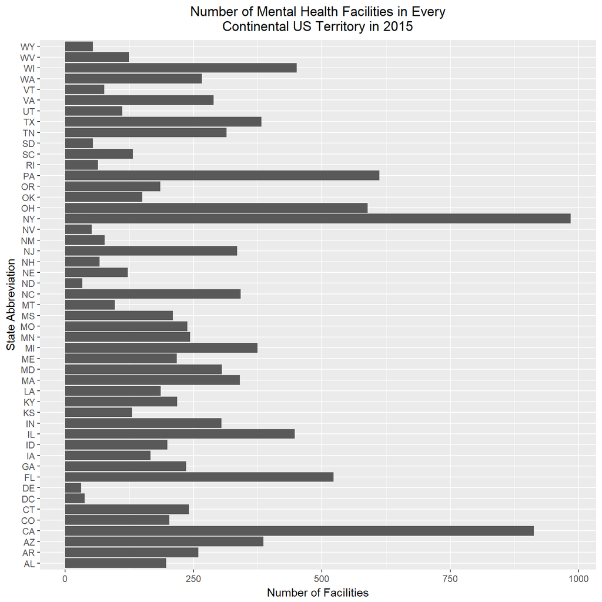

```r
# Use ggplot2 for plotting
require(ggplot2)
# Create ggplot object to plot as a horizontal bar plot
bars = ggplot(count_by_state,
              aes(x=State,
                  y=Facilities
                  )
              ) + geom_col() + coord_flip()

# Create meaningful axis and plot titles
bars + labs(x='State Abbreviation',
            y='Number of Facilities',
            title='Number of Mental Health Facilities in Every\nContinental US Territory in 2015'
            ) + theme(plot.title=element_text(hjust=0.5))
```

### **2:** Cleaning and Expanding the Dataset

The analysis so far only concerns the raw number of facilities in each state, but does not incorporate any other factors that might explain why some states have more facilities. One such factor is state area; it is reasonable to assume that larger states would require more mental health facilities to serve residents in all areas. To provide this data, the mental health facility data will be merged with a data set containing data on state size in square miles. The data will be merged by each state’s abbreviation.

```r
# Import statesize data
statesize = read.csv('statesize.csv', header=TRUE)

# Merge size data with hospital dataset by state abbreviation
df = merge(count_by_state, statesize, by.x='State', by.y='Abbrev')
```

This merge is not possible with the original data because each state abbreviation in column LST has spaces at the end (trailing white space). However, this aspect of the data was cleaned after the data was first imported, so we are able to merge the data without issue.

The data from the previous chart could be misleading, because it does not take into consideration the size of each state and larger states will likely require more facilities. To rectify this, the state size data will be used to calculate the number of hospitals per thousand square miles in each state.

```r
# Add a new variable to the merged dataset with the number of facilities per 1,000 square miles
df$per_1k_sq_miles = df$Facilities / (df$SqMiles / 1000)
```

The number of facilities per square mile in each state will be plotted in R. Furthermore, the plot will be color-coded by the geographic region of the United States that each state belongs to.

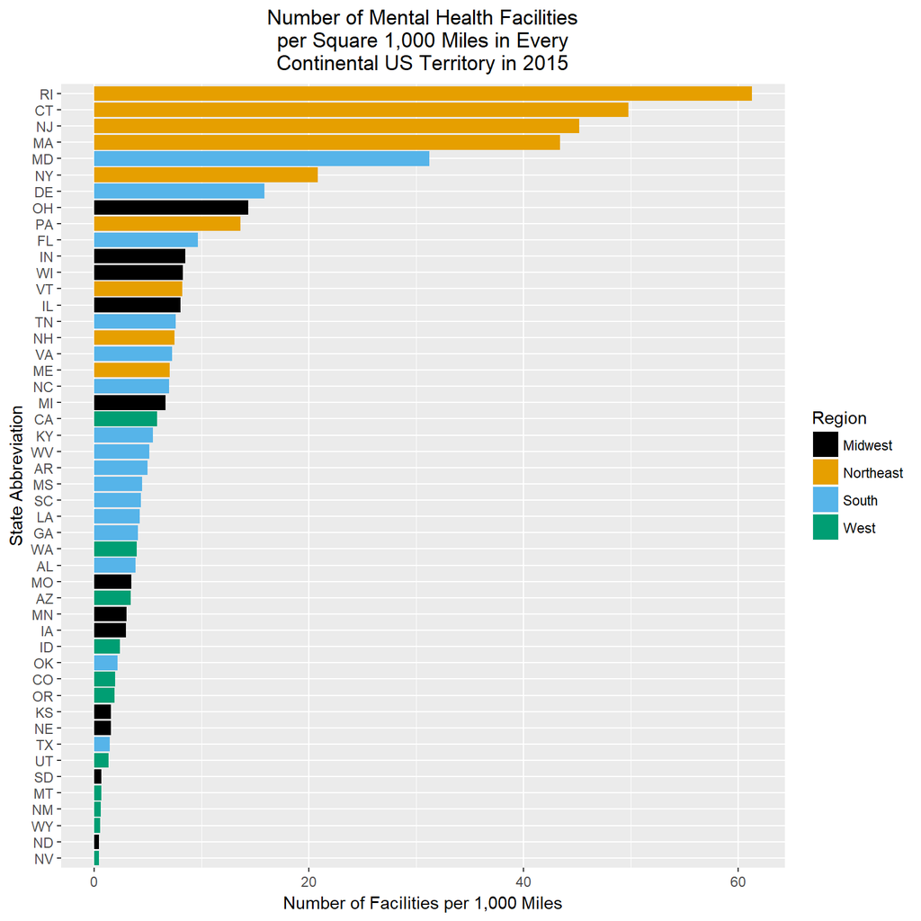

```r
# Define new ggplot2 color palette to be color-blind friendly
#   Taken from: http://www.cookbook-r.com/Graphs/Colors_(ggplot2)/
cb_friendly_colors = c("#000000", "#E69F00", "#56B4E9", "#009E73", "#F0E442", "#0072B2", "#D55E00", "#CC79A7")

# Create ggplot object to plot as a horizontal bar plot
#   Use color-blind friendly color palette to fill bars
#   Sort states in descending order of facilities per area
bars = ggplot(df,
              aes(x=reorder(State,
                            per_1k_sq_miles
                            ),
                  y=per_1k_sq_miles,
                  fill=Region
                  )
              ) + geom_col() + coord_flip() + scale_fill_manual(values=cb_friendly_colors)

# Create meaningful axis and plot titles
bars + labs(x='State Abbreviation',
            y='Number of Facilities per 1,000 Miles',
            title='Number of Mental Health Facilities\nper Square 1,000 Miles in Every\nContinental US Territory in 2015'
            ) + theme(plot.title=element_text(hjust=0.5))
```

### Conclusion

Based on this analysis of the data, it might at first glance appear that western states with few facilities per square mile are in desperate need of new VA hospitals. However, this may not necessarily be the case when population is considered. I would caution that further analysis involving state population is necessary before making decisions on where to build new VA mental clinics. Further research should consider the number of mental health facilities per capita or even the number of facilities per capita normalized to population density, to give a more complete picture of the need for additional VA hospitals in each state.